# Modeling with tidymodels in R - DataCamp

Edneide Ramalho

23/07/2023

[figure not shown]

# 1 Tracks for this course

- Machine Learning Fundamentals in R
- Machine Learning Scientist with R
- Supervised Machine Learning in R

# 2 Imports

```r
library(tidyverse)
library(tidymodels)
```

# 3 The tidymodels ecosystem

## 3.1 Collection of machine learning packages

- Data resampling: `rsample`
- Feature engineering: `recipes`
- Model fitting: `parsnip`
- Model Tuning: `tune` e `dials`
- Model evaluation: `yardstick`

## 3.2 Data resampling

Create training and tests sets

- Guards against **overfitting**
- Common ratio
  - 75% training
  - 25% test

**Training data**

- Feature engineering
- Model fitting and tunning

**Test data**

- Estimate model performance on new data

## 3.3 Fuel efficiency data

- Dataset: `mpg`
- Outcome variable: `hwy` (highway fuel efficiency in miles per gallon - mpg)

```r
glimpse(mpg)
```

```
## Rows: 234
## Columns: 11
## $ manufacturer <chr> "audi", "audi", "audi", "audi", "audi", "audi", "audi", "…
## $ model        <chr> "a4", "a4", "a4", "a4", "a4", "a4", "a4", "a4 quattro", "…
## $ displ        <dbl> 1.8, 1.8, 2.0, 2.0, 2.8, 2.8, 3.1, 1.8, 1.8, 2.0, 2.0, 2.…
## $ year         <int> 1999, 1999, 2008, 2008, 1999, 1999, 2008, 1999, 1999, 200…
## $ cyl          <int> 4, 4, 4, 4, 6, 6, 6, 4, 4, 4, 4, 6, 6, 6, 6, 6, 6, 8, 8, …
## $ trans        <chr> "auto(l5)", "manual(m5)", "manual(m6)", "auto(av)", "auto…
## $ drv          <chr> "f", "f", "f", "f", "f", "f", "f", "4", "4", "4", "4", "4…
## $ cty          <int> 18, 21, 20, 21, 16, 18, 18, 18, 16, 20, 19, 15, 17, 17, 1…
## $ hwy          <int> 29, 29, 31, 30, 26, 26, 27, 26, 25, 28, 27, 25, 25, 25, 2…
## $ fl           <chr> "p", "p", "p", "p", "p", "p", "p", "p", "p", "p", "p", "p…
## $ class        <chr> "compact", "compact", "compact", "compact", "compact", "c…
```

## 3.4 Data resampling with tidymodels

```r
mpg_split <- initial_split(mpg, prop = 0.75, strata = hwy)
```

- `prop`: specifies the proportion to place into training
- `strata`: provides stratification by t he outcome variable

```r
mpg_training <- mpg_split %>%
  training()

mpg_test <- mpg_split %>%
  testing()
```

## 3.5 Exercises - part 1

> 1. Creating training and test datasets

In this exercise, you will create training and test datasets from the `home_sales` data. This data contains information on homes sold in the Seattle, Washington area between 2015 and 2016.

```r
# data
home_sales <- readRDS('datasets/home_sales.rds')
glimpse(home_sales)
```

```
## Rows: 1,492
## Columns: 8
## $ selling_price <dbl> 487000, 465000, 411000, 635000, 380000, 495000, 355000, …
## $ home_age      <dbl> 10, 10, 18, 4, 24, 21, 19, 19, 11, 3, 24, 3, 16, 20, 29,…
## $ bedrooms      <dbl> 4, 3, 2, 3, 5, 3, 3, 3, 4, 4, 2, 4, 3, 3, 3, 5, 3, 3, 5,…
## $ bathrooms     <dbl> 2.50, 2.25, 2.00, 2.50, 2.50, 3.50, 2.25, 2.00, 2.50, 2.…
## $ sqft_living   <dbl> 2540, 1530, 1130, 3350, 2130, 1650, 1430, 2190, 1920, 23…
## $ sqft_lot      <dbl> 5001, 1245, 1148, 4007, 8428, 1577, 4777, 19800, 9000, 1…
## $ sqft_basement <dbl> 0, 480, 330, 800, 0, 550, 0, 0, 0, 0, 420, 0, 590, 1070,…
## $ floors        <dbl> 2, 2, 2, 2, 2, 2, 2, 1, 2, 1, 1, 2, 2, 1, 2, 2, 2, 1, 2,…
```

**Outcome variable**: `selling_price`

- Create an `rsample` object, `home_split`, that contains the instructions for randomly splitting the `home_sales` data into a training and test dataset.
- Allocate 70% of the data into training and stratify the results by `selling_price`.
- Create a training dataset from `home_split` called `home_training`.
- Check the number of rows in the training and test datasets by passing them into the `nrow()` function.

```r
# Create a data split object
home_split <- initial_split(home_sales,
                  prop = 0.7,
                  strata = selling_price)

# Create the training data
home_training <- home_split %>%
 training()

# Create the test data
home_test <- home_split %>%
  testing()


# Check number of rows in each dataset
print(paste0("#Rows Train: ", nrow(home_training)))
```

```
## [1] "#Rows Train: 1042"
```

```r
print(paste0("#Rows Test: ", nrow(home_test)))
```

```
## [1] "#Rows Test: 450"
```

> 2. Distribution of outcome variables values

Stratifying by the outcome variable when generating training and test datasets ensures that the outcome variable values have a similar range in both datasets.

Since the original data is split at random, stratification avoids placing all the expensive homes in `home_sales` into the test dataset, for example. In this case, your model would most likely perform poorly because it was trained on less expensive homes.

- Calculate the minimum, maximum, mean, and standard deviation of the `selling_price` variable in `home_training`.
- Calculate the minimum, maximum, mean, and standard deviation of the `selling_price` variable in `home_test`.

```r
# Distribution of selling_price in training data
home_training %>%
  summarize(min_sell_price = min(selling_price),
            max_sell_price = max(selling_price),
            mean_sell_price = mean(selling_price),
            sd_sell_price = sd(selling_price))
```

| min_sell_price | max_sell_price | mean_sell_price | sd_sell_price |
| --- | --- | --- | --- |
| 350000 | 650000 | 478841.2 | 80015.97 |

```r
# Distribution of selling_price in test data
home_test %>%
  summarize(min_sell_price = min(selling_price),
            max_sell_price = max(selling_price),
            mean_sell_price = mean(selling_price),
            sd_sell_price = sd(selling_price))
```

| min_sell_price | max_sell_price | mean_sell_price | sd_sell_price |
| --- | --- | --- | --- |
| 350000 | 650000 | 479647.9 | 83253.69 |

- The values are similar, insuring that we have a good stratification.

# 4 Linear regression with tidymodels

## 4.1 The parsnip package

1. Specify the model type
   - Linear regression or other
2. Specify engine
   - Different engines correspond to different underlying R packages
3. Specify the mode
   - Either regression or classification

Example:

```r
# Training model
lm_model <- linear_reg() %>%
  set_engine('lm') %>%
  set_mode('regression')

lm_fit <- lm_model %>%
  fit(hwy ~ cty, data = mpg_training)

tidy(lm_fit)
```

| term | estimate | std.error | statistic | p.value |
| --- | --- | --- | --- | --- |
| (Intercept) | 0.6429478 | 0.53002284 | 1.213057 | 2.267812e-01 |
| cty | 1.3468669 | 0.03051282 | 44.141012 | 2.149358e-95 |

```r
# Prediction
hwy_predictions <- lm_fit %>%
  predict(new_data = mpg_test)
hwy_predictions
```

| .pred |
| --- |
| 27.58029 |
| 26.23342 |
| 20.84595 |
| 20.84595 |
| 23.53968 |
| 19.49908 |
| 22.19282 |
| 15.45848 |
| 15.45848 |
| 24.88655 |

[output cut: 51 more lines]

```r
# Adding predictions to the test dataset
mpg_test_results <- mpg_test %>%
  select(hwy, cty) %>%
  bind_cols(hwy_predictions)
mpg_test_results
```

| hwy | cty | .pred |
| --- | --- | --- |
| 31 | 20 | 27.58029 |
| 27 | 19 | 26.23342 |
| 25 | 15 | 20.84595 |
| 24 | 15 | 20.84595 |
| 25 | 17 | 23.53968 |
| 20 | 14 | 19.49908 |
| 26 | 16 | 22.19282 |
| 14 | 11 | 15.45848 |
| 15 | 11 | 15.45848 |
| 29 | 18 | 24.88655 |

[output cut: 51 more lines]

## 4.2 Exercises - part 2

> 3. **Fitting a linear regression model**

The `parsnip` package provides a unified syntax for the model fitting process in R.

With `parsnip`, it is easy to define models using the various packages, or engines, that exist in the R ecosystem.

In this exercise, you will define a `parsnip` linear regression object and train your model to predict `selling_price` using `home_age` and `sqft_living` as predictor variables from the `home_sales` data.

- Initialize a linear regression object, `linear_model`, with the appropriate `parsnip` function.
- Use the `lm` engine.
- Set the mode to `regression`.
- Train your model to predict `selling_price` using `home_age` and `sqft_living` as predictor variables from the `home_training` dataset.
- Print `lm_fit` to view the model information.
- Create a tibble, `home_predictions`, that contains the predicted selling prices of homes in the test dataset.
- Create a tibble with the `selling_price`, `home_age`, and `sqft_living` columns from the test dataset and the predicted home selling prices.

```r
# Initialize a linear regression object, linear_model
linear_model <- linear_reg() %>%
  # Set the model engine
  set_engine('lm') %>%
  # Set the model mode
  set_mode('regression')

# Fit the model using the training data
lm_fit <- linear_model %>%
  fit(selling_price ~ home_age + sqft_living,
      data = home_training)

# Print lm_fit to view model information
lm_fit
```

```
## parsnip model object
##
##
## Call:
## stats::lm(formula = selling_price ~ home_age + sqft_living, data = data)
##
## Coefficients:
## (Intercept)     home_age  sqft_living
##    292825.1      -1628.1        103.9
```

```r
# Predict selling_price
home_predictions <- predict(lm_fit,
                        new_data = home_test)

# View predicted selling prices
home_predictions
```

| .pred |
| --- |
| 634223.9 |
| 429995.2 |
| 489332.4 |
| 474316.3 |
| 426598.6 |
| 407764.4 |
| 390417.8 |
| 405070.2 |
| 405265.9 |
| 400564.8 |

[output cut: 440 more lines]

```r
# Combine test data with predictions
home_test_results <- home_test %>%
  select(selling_price, home_age, sqft_living) %>%
  bind_cols(home_predictions)

# View results
home_test_results
```

| selling_price | home_age | sqft_living | .pred |
| --- | --- | --- | --- |
| 635000 | 4 | 3350 | 634223.9 |
| 495000 | 21 | 1650 | 429995.2 |
| 464950 | 19 | 2190 | 489332.4 |
| 425000 | 11 | 1920 | 474316.3 |
| 381000 | 25 | 1680 | 426598.6 |
| 452000 | 27 | 1530 | 407764.4 |
| 391000 | 30 | 1410 | 390417.8 |
| 377500 | 21 | 1410 | 405070.2 |
| 375000 | 33 | 1600 | 405265.9 |
| 355000 | 26 | 1445 | 400564.8 |

[output cut: 440 more lines]

# 5 Evaluating model performance

- We’re gonna use the table with results, like the table below, with the real outcome values and the predictions:

```r
mpg_test_results
```

| hwy | cty | .pred |
| --- | --- | --- |
| 31 | 20 | 27.58029 |
| 27 | 19 | 26.23342 |
| 25 | 15 | 20.84595 |
| 24 | 15 | 20.84595 |
| 25 | 17 | 23.53968 |
| 20 | 14 | 19.49908 |
| 26 | 16 | 22.19282 |
| 14 | 11 | 15.45848 |
| 15 | 11 | 15.45848 |
| 29 | 18 | 24.88655 |

[output cut: 51 more lines]

## 5.1 Root mean squared error (RMSE)

Estimates the average prediction error

```r
mpg_test_results %>%
  rmse(truth = hwy, estimate = .pred)
```

| .metric | .estimator | .estimate |
| --- | --- | --- |
| rmse | standard | 1.892325 |

## 5.2 R squared metric

- Coefficient of determination
- Ranges from 0 to 1
  - Calculated with `rsq()` function from `yardstick`

```r
mpg_test_results %>%
  rsq(truth = hwy, estimate = .pred)
```

| .metric | .estimator | .estimate |
| --- | --- | --- |
| rsq | standard | 0.9003483 |

## 5.3 Plotting R squared plots

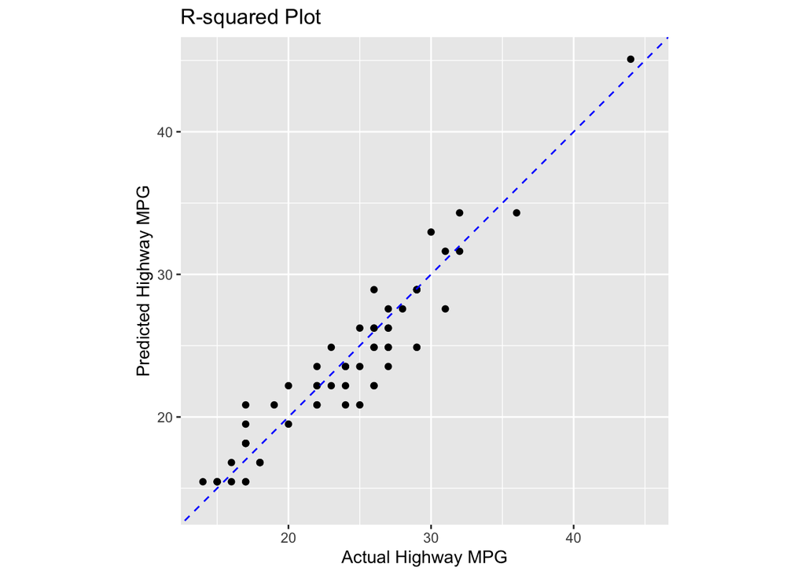

```r
mpg_test_results %>%
  ggplot(aes(x = hwy, y = .pred)) +
  geom_point() +
  geom_abline(color = 'blue', linetype = 2) +
  coord_obs_pred() + # axis in the same scale
  labs(title = 'R-squared Plot',
       y = 'Predicted Highway MPG',
       x = 'Actual Highway MPG')
```

## 5.4 Streamilining model fitting

The `last_fit()` function:

- Takes a model specification, model formula, and data split object
- Performs the following:
  1. Creates training and test datasets
  2. Fits the model to the training data
  3. Calculates the metrics and predictions on the test data
  4. Returns an object with all results

```r
lm_last_fit <- lm_model %>%
  last_fit(hwy ~ cty,
           split = mpg_split)
```

## 5.5 Collecting metrics

```r
lm_last_fit %>%
  collect_metrics()
```

| .metric | .estimator | .estimate | .config |
| --- | --- | --- | --- |
| rmse | standard | 1.8923250 | Preprocessor1_Model1 |
| rsq | standard | 0.9003483 | Preprocessor1_Model1 |

## 5.6 Collecting predictions

```r
lm_last_fit %>%
  collect_predictions()
```

| id | .pred | .row | hwy | .config |
| --- | --- | --- | --- | --- |
| train/test split | 27.58029 | 3 | 31 | Preprocessor1_Model1 |
| train/test split | 26.23342 | 11 | 27 | Preprocessor1_Model1 |
| train/test split | 20.84595 | 15 | 25 | Preprocessor1_Model1 |
| train/test split | 20.84595 | 16 | 24 | Preprocessor1_Model1 |
| train/test split | 23.53968 | 17 | 25 | Preprocessor1_Model1 |
| train/test split | 19.49908 | 21 | 20 | Preprocessor1_Model1 |
| train/test split | 22.19282 | 24 | 26 | Preprocessor1_Model1 |
| train/test split | 15.45848 | 30 | 14 | Preprocessor1_Model1 |
| train/test split | 15.45848 | 31 | 15 | Preprocessor1_Model1 |
| train/test split | 24.88655 | 36 | 29 | Preprocessor1_Model1 |

[output cut: 51 more lines]

## 5.7 Exercises - part 3

> 4. **Model performance metrics**

Evaluating model results is an important step in the modeling process. Model evaluation should be done on the test dataset in order to see how well a model will generalize to new datasets.

In the previous exercise, you trained a linear regression model to predict `selling_price` using `home_age` and `sqft_living` as predictor variables. You then created the `home_test_results` tibble using your trained model on the `home_test` data.

In this exercise, you will calculate the RMSE and R squared metrics using your results in `home_test_results`.

- Execute the first two lines of code which print the `home_test_results`. This tibble contains the actual and predicted home selling prices in the `home_test` dataset.
- Using `home_test_results`, calculate the RMSE and R squared metrics.

```r
# Print home_test_results
home_test_results
```

| selling_price | home_age | sqft_living | .pred |
| --- | --- | --- | --- |
| 635000 | 4 | 3350 | 634223.9 |
| 495000 | 21 | 1650 | 429995.2 |
| 464950 | 19 | 2190 | 489332.4 |
| 425000 | 11 | 1920 | 474316.3 |
| 381000 | 25 | 1680 | 426598.6 |
| 452000 | 27 | 1530 | 407764.4 |
| 391000 | 30 | 1410 | 390417.8 |
| 377500 | 21 | 1410 | 405070.2 |
| 375000 | 33 | 1600 | 405265.9 |
| 355000 | 26 | 1445 | 400564.8 |

[output cut: 440 more lines]

```r
# Calculate the RMSE metric
home_test_results %>%
  rmse(selling_price, .pred)
```

| .metric | .estimator | .estimate |
| --- | --- | --- |
| rmse | standard | 49593.44 |

```r
# Calculate the R squared metric
home_test_results %>%
  rsq(selling_price, .pred)
```

| .metric | .estimator | .estimate |
| --- | --- | --- |
| rsq | standard | 0.645462 |

> 5. **R squared plot**

Calculating the R squared value is only the first step in studying your model’s predictions.

Making an R squared plot is extremely important because it will uncover potential problems with your model, such as non-linear patterns or regions where your model is either over or under-predicting the outcome variable.

In this exercise, you will create an R squared plot of your model’s performance.

- Create an R squared plot of your model’s performance. The x-axis should have the actual selling price and the y-axis should have the predicted values.
- Use the appropriate functions to add the line y = x to your plot and standardize the range of both axes.

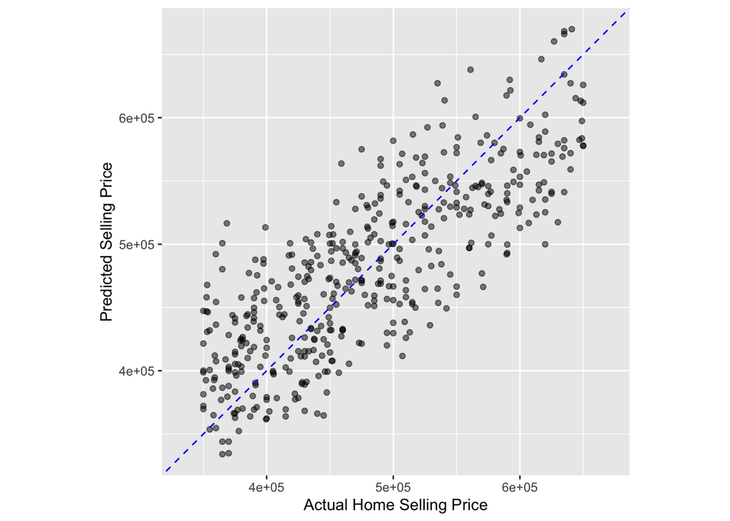

```r
# Create an R squared plot of model performance
ggplot(home_test_results, aes(x = selling_price, y = .pred)) +
  geom_point(alpha = 0.5) +
  geom_abline(color = 'blue', linetype = 2) +
  coord_obs_pred() +
  labs(x = 'Actual Home Selling Price', y = 'Predicted Selling Price')
```

> 6. **Complete model fitting process with last_fit()**

In this exercise, you will train and evaluate the performance of a linear regression model that predicts `selling_price` using all the predictors available in the `home_sales` tibble.

This exercise will give you a chance to perform the entire model fitting process with `tidymodels`, from defining your model object to evaluating its performance on the test data.

Earlier in the chapter, you created an `rsample` object called `home_split` by passing the `home_sales` tibble into `initial_split()`. The `home_split` object contains the instructions for randomly splitting `home_sales` into training and test sets.

- Use the `linear_reg()` function to define a linear regression model object. Use the `lm` engine.
- Train your linear regression object with the `last_fit()` function.
- In your model formula, use `selling_price` as the outcome variable and all other columns as predictor variables.
- Create a tibble with the model’s predictions on the test data.
- Create an R square plot of the model’s performance. The x-axis should have the actual selling price and the y-axis should have the predicted values.

```r
# Define a linear regression model
linear_model <- linear_reg() %>%
  set_engine('lm') %>%
  set_mode('regression')

# Train linear_model with last_fit()
linear_fit <- linear_model %>%
  last_fit(selling_price ~ ., split = home_split)

# Collect predictions and view results
predictions_df <- linear_fit %>% collect_predictions()
predictions_df
```

| id | .pred | .row | selling_price | .config |
| --- | --- | --- | --- | --- |
| train/test split | 692863.1 | 4 | 635000 | Preprocessor1_Model1 |
| train/test split | 438686.5 | 6 | 495000 | Preprocessor1_Model1 |
| train/test split | 481866.7 | 8 | 464950 | Preprocessor1_Model1 |
| train/test split | 440740.0 | 9 | 425000 | Preprocessor1_Model1 |
| train/test split | 398036.3 | 18 | 381000 | Preprocessor1_Model1 |
| train/test split | 408316.5 | 23 | 452000 | Preprocessor1_Model1 |
| train/test split | 384706.8 | 29 | 391000 | Preprocessor1_Model1 |
| train/test split | 395553.1 | 32 | 377500 | Preprocessor1_Model1 |
| train/test split | 410892.5 | 33 | 375000 | Preprocessor1_Model1 |
| train/test split | 394413.0 | 37 | 355000 | Preprocessor1_Model1 |

[output cut: 440 more lines]

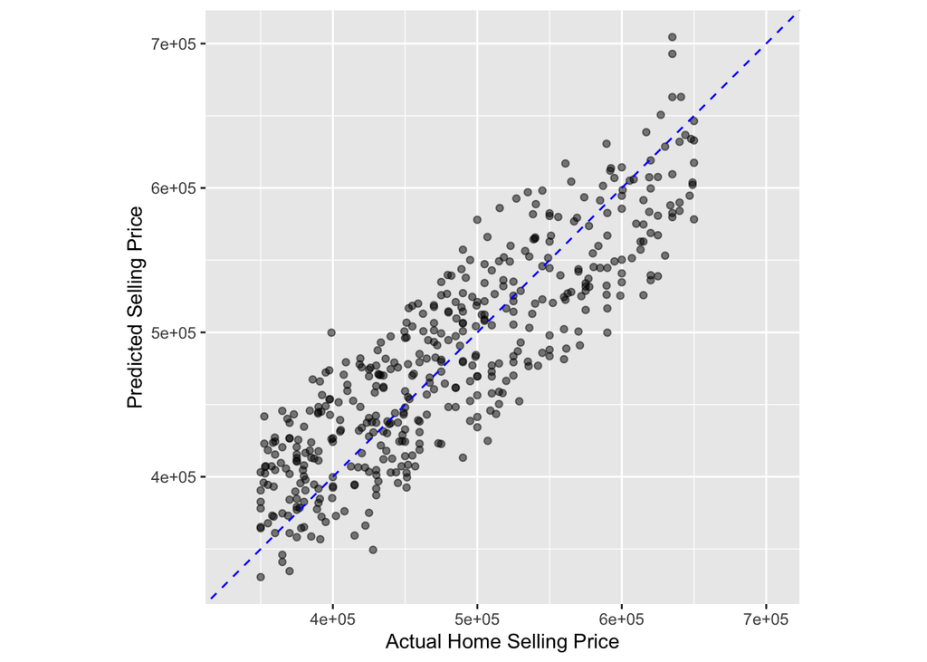

```r
# Make an R squared plot using predictions_df
ggplot(predictions_df, aes(x = selling_price, y = .pred)) +
  geom_point(alpha = 0.5) +
  geom_abline(color = 'blue', linetype = 2) +
  coord_obs_pred() +
  labs(x = 'Actual Home Selling Price', y = 'Predicted Selling Price')
```